# 非流动性因子测试

陶阿明

2016/11/28

## 一、因子综述

### (一)因子简介

非流动性因子比较简单，但效果非常好，即每天个股涨跌幅的绝对值除以当日成交额，再取过去一个月的平均值。

### (二)因子效果展示

因子IC序列如下图所示：

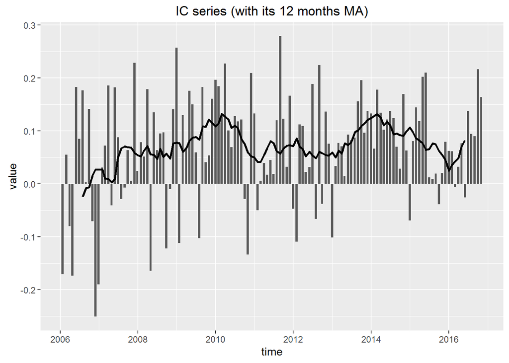

因子分组的年化收益率如下图所示：

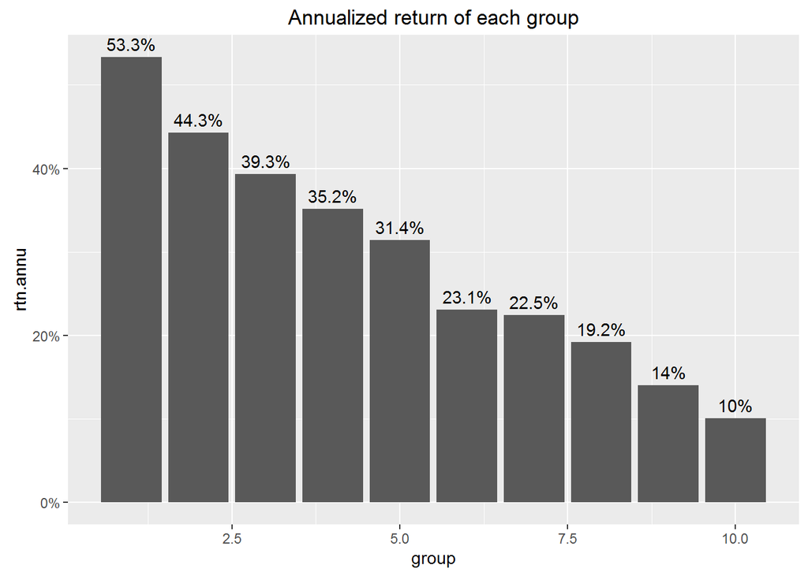

因子多空收益如下图所示：

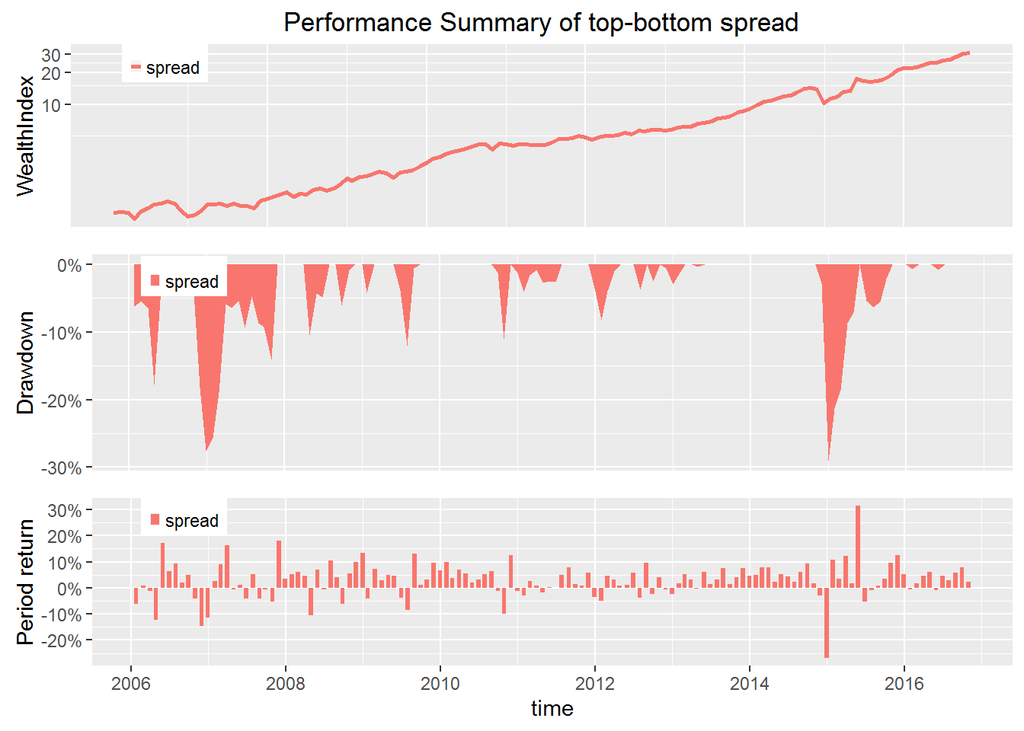

### (三)纯因子组合

上述因子IC、因子分组、因子多空组合不能剥离行业、市值等风格特征。下面构建的纯因子组合是剔除了市值、行业、估值等风险特征的纯因子组合，更能有效的反映因子的alpha性。

纯因子组合收益率如下图所示：

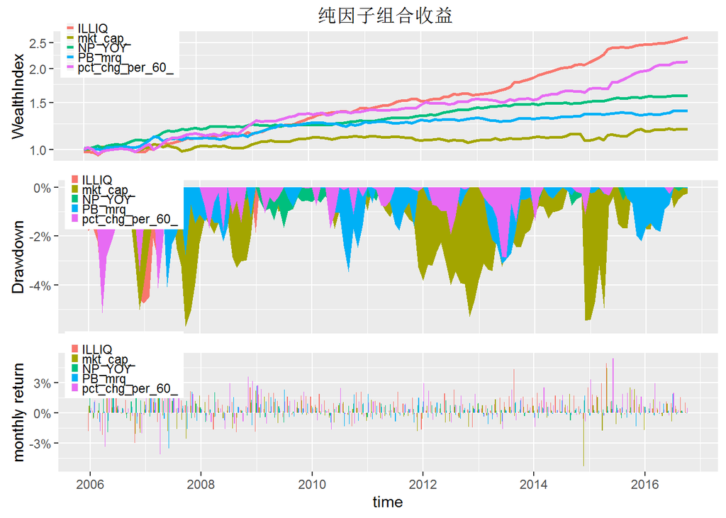

纯因子组合收益率统计如下表：

|  | ILLIQ | mkt_cap_ | NP_YOY | PB_mrq_ | pct_chg_per_60_ |
| --- | --- | --- | --- | --- | --- |
| 2005-12-30 ~ 2005-12-30 | -1.8% | 0.7% | 1.7% | 0.2% | 0.5% |
| 2006-01-25 ~ 2006-12-29 | -0.1% | -1.1% | 7.1% | 2.5% | -0.4% |
| 2007-01-31 ~ 2007-12-28 | 12.6% | 2.8% | 10.6% | 7.6% | 14.7% |
| 2008-01-31 ~ 2008-12-31 | 3.3% | 2.5% | 3.3% | 3.8% | 9.3% |
| 2009-01-23 ~ 2009-12-31 | 14.7% | 5.2% | -0.6% | 9.6% | 8.6% |
| 2010-01-29 ~ 2010-12-31 | 9.1% | 0.6% | 3.5% | 0.8% | 2.3% |
| 2011-01-31 ~ 2011-12-30 | 6.3% | -2.6% | 4.8% | 1.7% | 5.4% |
| 2012-01-31 ~ 2012-12-31 | 5.6% | 0% | 6.9% | 2% | 5.2% |
| 2013-01-31 ~ 2013-12-31 | 15.8% | 2.9% | 3.3% | -0.9% | -0.8% |
| 2014-01-30 ~ 2014-12-31 | 14.2% | -2.7% | 2.2% | 4% | 10.3% |
| 2015-01-30 ~ 2015-12-31 | 16.6% | 8.1% | 4% | 0% | 16.2% |
| 2016-01-29 ~ 2016-09-30 | 6.3% | 2% | 1.1% | 3% | 8.1% |
| Cumulative Return | 162.6% | 19.4% | 59% | 39.6% | 112.5% |
| Annualized Return | 9.3% | 1.6% | 4.4% | 3.1% | 7.2% |
| Annualized StdDev | 4.2% | 3.9% | 2.3% | 3.3% | 4.8% |
| Annualized Sharpe(Rf=0%) | 222% | 42.2% | 189.1% | 93.6% | 149.5% |
| Worst Drawdown | 4.8% | 5.7% | 1.9% | 4.1% | 5.1% |

## 二、核心指数回测

上面的测试都是全市场测试，下面将在沪深300和中证500里面分别测试因子的效果。

### (一)沪深300

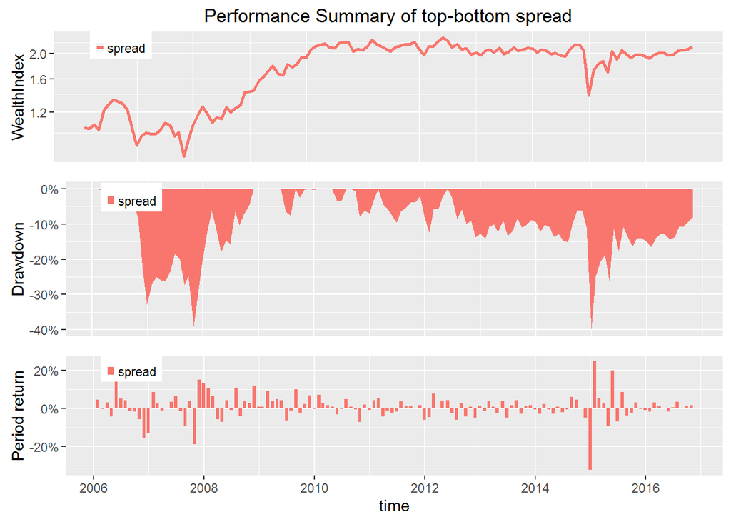

### (二)中证500

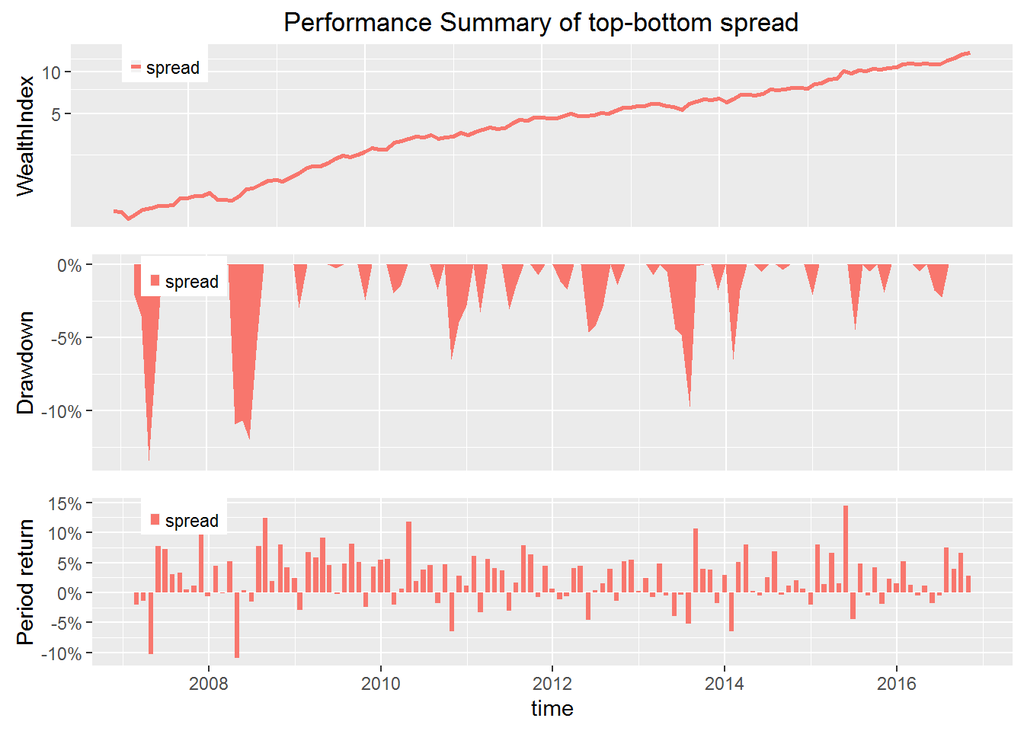

### (三)指数统计

两个指数中因子的IC统计和因子的多空组合收益率如下表所示

|  | EI000300 | EI000905 |
| --- | --- | --- |
| IC均值 | 0.020 | 0.055 |
| IC标准差 | 0.130 | 0.113 |
| ICIR | 0.156 | 0.487 |
| IC胜率 | 0.554 | 0.684 |
| 多空组合年化收益 | 0.072 | 0.309 |
| 多空组合年化波动率 | 0.231 | 0.152 |
| 多空组合年化夏普 | 0.310 | 2.037 |
| 多空组合最大回撤 | 0.398 | 0.134 |

## 三、大类行业回测

### (一)大周期

大周期覆盖农林牧渔、采掘、化工、钢铁、有色金属。

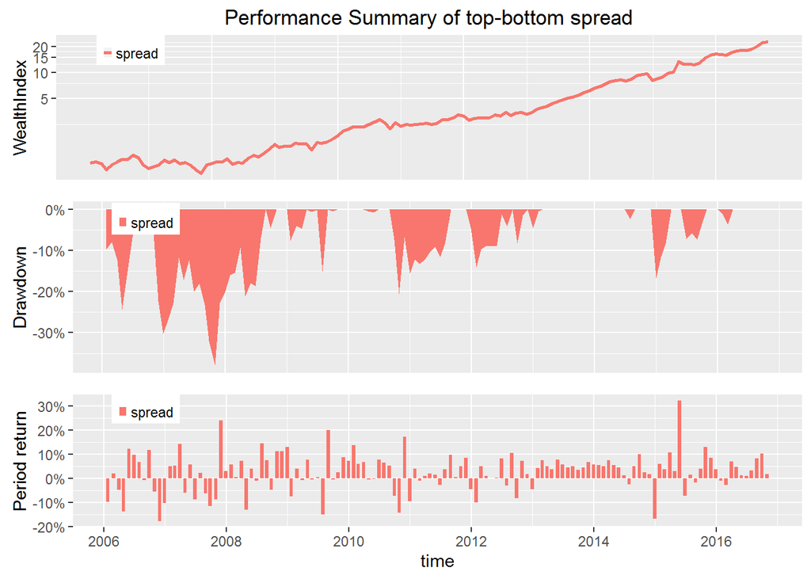

### (二)金融地产

金融地产组覆盖银行、非银、房地产。

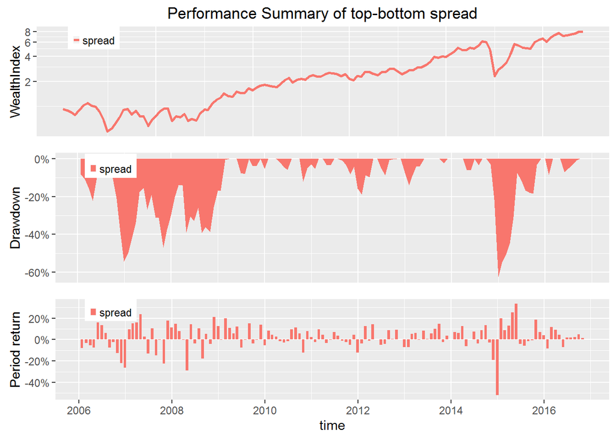

### (三)TMT

TMT覆盖电子、计算机、传媒、通信。

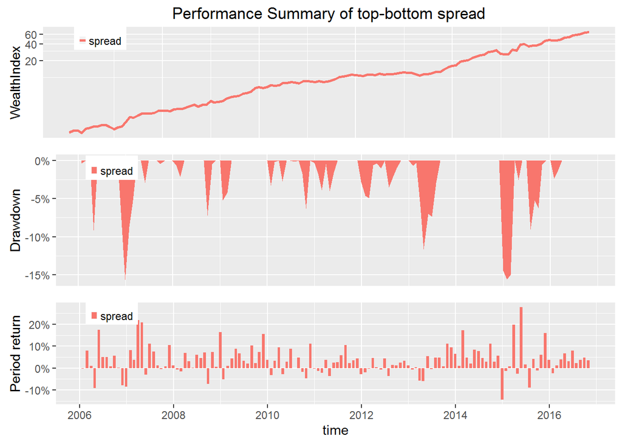

### (四)大消费

大消费覆盖汽车、家用电器、食品饮料、纺织服装、休闲服务、医药生物、商业贸易。

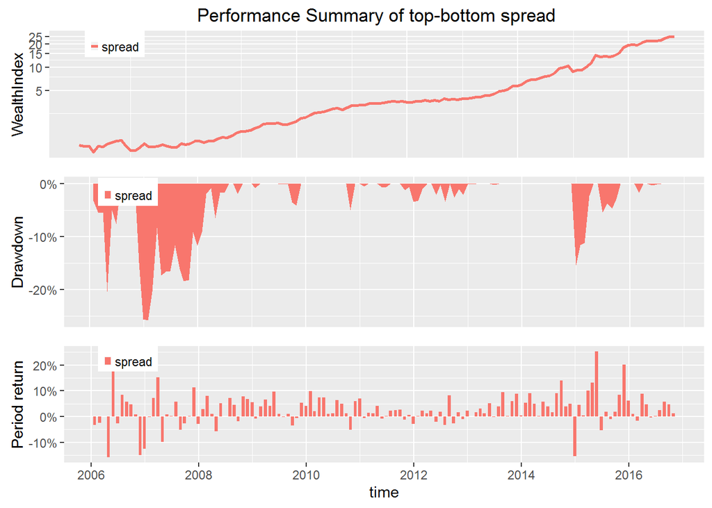

### (五)制造组

制造组覆盖轻工制造、建筑材料、建筑建材、电气设备、机械设备、国防军工。

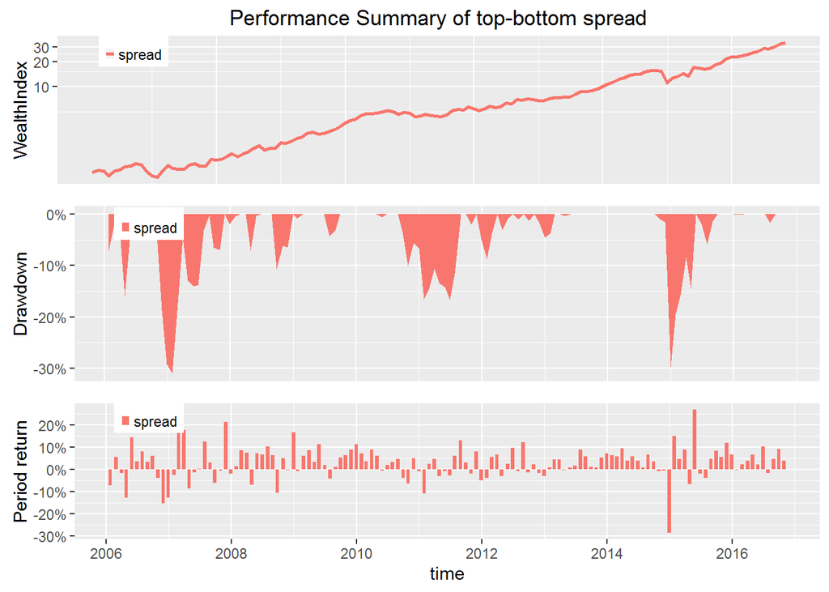

### (六)其他

其他覆盖公共事业、交通运输、综合。

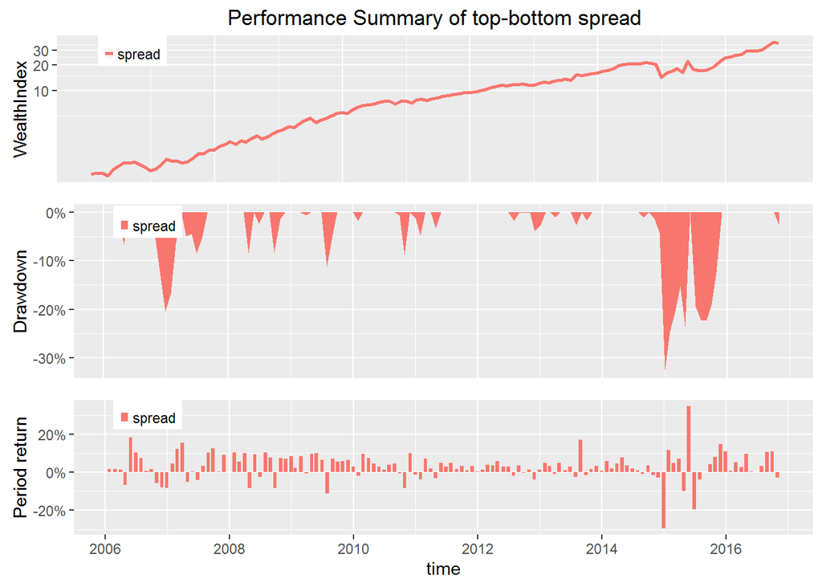

### (七)行业统计

大类行业中因子的IC统计和因子的多空组合收益率如下表所示

|  | 周期 | 金融地产 | TMT | 消费 | 制造 | 其他 |
| --- | --- | --- | --- | --- | --- | --- |
| IC均值 | 0.062 | 0.052 | 0.073 | 0.067 | 0.076 | 0.069 |
| IC标准差 | 0.151 | 0.185 | 0.135 | 0.121 | 0.133 | 0.135 |
| ICIR | 0.407 | 0.283 | 0.543 | 0.556 | 0.572 | 0.513 |
| IC胜率 | 0.723 | 0.577 | 0.731 | 0.723 | 0.708 | 0.677 |
| 多空组合年化收益 | 0.335 | 0.212 | 0.473 | 0.346 | 0.384 | 0.394 |
| 多空组合年化波动率 | 0.270 | 0.392 | 0.220 | 0.206 | 0.251 | 0.247 |
| 多空组合年化夏普 | 1.239 | 0.541 | 2.143 | 1.681 | 1.531 | 1.595 |
| 多空组合最大回撤 | 0.378 | 0.624 | 0.157 | 0.258 | 0.309 | 0.325 |